# tarea_5

```python
import warnings
warnings.filterwarnings('ignore')

# Libs
from collections import Counter
import pandas as pd
import numpy as np
import matplotlib.pyplot as plt
import seaborn as sns
import re
import itertools

# Help cleaning data
from sklearn import preprocessing

# For feature selection
from sklearn.svm import LinearSVC
from sklearn.feature_selection import SelectFromModel

# For cross-validation
from sklearn.model_selection import cross_val_score,train_test_split

# Models
from sklearn.discriminant_analysis import LinearDiscriminantAnalysis, QuadraticDiscriminantAnalysis
from sklearn import tree
from sklearn.naive_bayes import GaussianNB
from sklearn.linear_model import LogisticRegression
from sklearn.svm import LinearSVC, SVC

# Metrics
from sklearn.metrics import confusion_matrix, roc_curve, auc, precision_recall_curve, average_precision_score


pd.options.display.max_columns = None

from imblearn.over_sampling import SMOTE, ADASYN, SMOTENC
```

### Lectura de datos

```python
loan_stats = pd.read_csv('data/LoanStats_2018Q1.csv')
data = loan_stats
```

### EDA

Comenzamos por hacer una pairplot para las variables:

- loan amount
- amount funded
- total committed by investors.

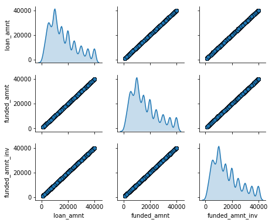

```python
sns.pairplot(loan_stats[['loan_amnt','funded_amnt','funded_amnt_inv']],
                 size=1.8, aspect=1.2,
                 plot_kws=dict(edgecolor="k", linewidth=0.5),
                 diag_kws=dict(shade=True),
                 diag_kind = "kde")
```

Y la relación entre ingreso anual y cantidad de préstamo

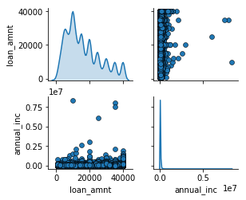

```python
sns.pairplot(loan_stats[['loan_amnt','annual_inc']],
                 size=1.8, aspect=1.2,
                 plot_kws=dict(edgecolor="k", linewidth=0.5),
                 diag_kws=dict(shade=True),
                 diag_kind = "kde")
```

La similaridad entre distribuciones indica que hay un balance adecuado entre crédito e inversión.

Continuaos analizando el propósito del préstamo

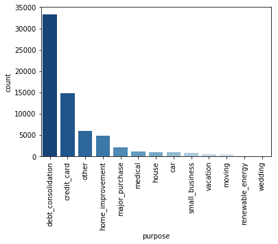

```python
g = sns.countplot(loan_stats['purpose'],
                  order = loan_stats['purpose'].value_counts().index,
                  palette = reversed(sns.color_palette("Blues", n_colors=13)))
labels = g.set_xticklabels(g.get_xticklabels(), rotation=90)
```

Hay tan solo 13 propósitos y la mayoría de los préstamos se concentra en consolidación de deuda y tarjetas de crétido

Con qué tipos de status de préstamos contamos?

```python
list(loan_stats['loan_status'].unique())
```

```
['Current',
 'Fully Paid',
 'Late (31-120 days)',
 'In Grace Period',
 'Charged Off',
 'Late (16-30 days)',
 'Default']
```

Los dividimos en 3 tipos

1. Fully paid: Prestamos pagados en tiempo y forma
2. Late - In Grace Period - Default - Charged off: Casos en que NO fue pagado en tiempo y forma
3. Préstamos vigentes

¿Cuál es la frecuencia de estos 3 tipos?

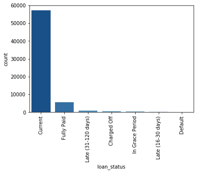

```python
g = sns.countplot(loan_stats['loan_status'],
                  order = loan_stats['loan_status'].value_counts().index,
                  palette = reversed(sns.color_palette("Blues", n_colors=7)))
labels = g.set_xticklabels(g.get_xticklabels(), rotation=90)
```

La gran mayoría son préstamos vigentes, ¿Cuál es la frecuencia de los préstamos que sí sabemos el estatus?

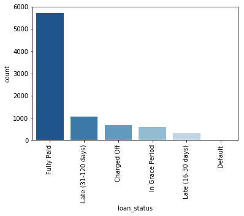

```python
filter_str = "not loan_status == 'Current'"
g = sns.countplot(loan_stats.query(filter_str)['loan_status'],
                  order = loan_stats.query(filter_str)['loan_status'].value_counts().index,
                  palette = reversed(sns.color_palette("Blues", n_colors=6)))
labels = g.set_xticklabels(g.get_xticklabels(), rotation=90)
```

Continuamos con el análisis. En general ¿cuáles son las calificaciones de los préstamos

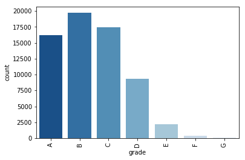

```python
g = sns.countplot(loan_stats['grade'],
                  order=sorted(list(loan_stats.grade.unique())),
                  palette = reversed(sns.color_palette("Blues", n_colors=7)))
labels = g.set_xticklabels(g.get_xticklabels(), rotation=90)
```

El grade más otorgado es B, seguido de cerca por C y A. Los demás decrecen rápidamente.

¿Cuál es la relación entre la calificación y si el préstamo fue (o no) pagado? Para cada grade grafiquemos la proporción entre préstamos asignados a dicho grade y la prestamos completamente pagados.

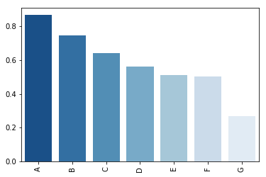

```python
total_counts = dict(Counter(loan_stats.query("not loan_status == 'Current'")['grade']))
paid_counts  = dict(Counter(loan_stats.query("loan_status == 'Fully Paid'")['grade']))
proportions = {grade:paid_counts[grade]/total_counts[grade] for grade in total_counts}
grade,proportions = zip(*sorted(zip(proportions.keys(), proportions.values())))

g = sns.barplot(x = list(grade),
                y = list(proportions),
                palette = reversed(sns.color_palette("Blues", n_colors=7)))
labels = g.set_xticklabels(g.get_xticklabels(), rotation=90)
```

Obtenemos lo esperado, a mejor grade, la proporción entre pagados y totales es mayor.

¿Cómo es la relación en aquellos que no fueron pagados en tiempo?

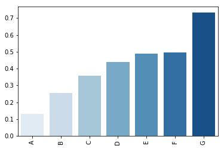

```python
total_counts = dict(Counter(loan_stats.query("not loan_status == 'Current'")['grade']))
paid_counts  = dict(Counter(loan_stats.query("not loan_status == 'Fully Paid' and not loan_status == 'Current'")['grade']))
proportions = {grade:paid_counts[grade]/total_counts[grade] for grade in total_counts}
grade,proportions = zip(*sorted(zip(proportions.keys(), proportions.values())))

g = sns.barplot(x = list(grade),
                y = list(proportions),
                palette = sns.color_palette("Blues", n_colors=7))
labels = g.set_xticklabels(g.get_xticklabels(), rotation=90)
```

Una vez más, obtenemos lo esperado. A peor grade la proporción entre totales y no-pagados es mayor.

Repitamos el análisis con subgrade

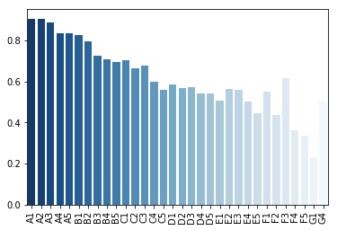

```python
total_counts = dict(Counter(loan_stats.query("not loan_status == 'Current'")['sub_grade']))
paid_counts  = dict(Counter(loan_stats.query("loan_status == 'Fully Paid'")['sub_grade']))
proportions = {subgrade:paid_counts[subgrade]/total_counts[subgrade] for subgrade in total_counts}
subgrades,proportions = zip(*sorted(zip(proportions.keys(), proportions.values())))

g = sns.barplot(x = list(subgrades),
                y = list(proportions),
                palette = reversed(sns.color_palette("Blues", n_colors=32)))
labels = g.set_xticklabels(g.get_xticklabels(), rotation=90)
```

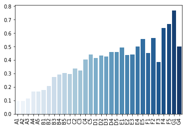

```python
total_counts = dict(Counter(loan_stats.query("not loan_status == 'Current'")['sub_grade']))
paid_counts  = dict(Counter(loan_stats.query("not loan_status == 'Fully Paid' and not loan_status == 'Current'")['sub_grade']))
proportions = {subgrade:paid_counts[subgrade]/total_counts[subgrade] for subgrade in total_counts}
subgrades,proportions = zip(*sorted(zip(proportions.keys(), proportions.values())))

g = sns.barplot(x = list(subgrades),
                y = list(proportions),
                palette = sns.color_palette("Blues", n_colors=32))
labels = g.set_xticklabels(g.get_xticklabels(), rotation=90)
```

Aquí ya se alcanzan a ver pequeñas inconsistencias pero en general la valoración es buena. ¿Se puede mejorar?

### Limpieza de datos

Comenzaremos por investigar que variables de tipo string son útiles para el modelo y las modificaremos a números enteros, variables categóricas o variables ordinales según sea el caso

Mapeamos los valores de $\textit{loan_status}$ a 0 si el préstamo ya fue pagado, a 1 si está en retraso o no fue pagado y a -1 si es un préstamo vigente. Los pertenecientes a la última categoría son los que serán clasificados posteriormente dentro de los grupos 0 y 1.

```python
d = {
     'Charged Off':1,
     'Current':-1,
     'Default':1,
     'Fully Paid':0,
     'In Grace Period':1,
     'Late (16-30 days)':1,
     'Late (31-120 days)':1
    }
data['loan_status'] = data['loan_status'].map(d)
```

La variable $\textit{term}$ contiene el plazo del prestamo (36 months, 60 months, ... ) la modificamos de forma que pueda ser interpretada como un entero

```python
data['term'] = data['term'].apply(lambda data: int(data.replace(' months','')))
```

La variable $\textit{int_rate}$ contiene la tasa de interés del préstamo como un porcentaje, la modificamos de forma que pueda ser interpretada como un número real

```python
data['int_rate'] = data['int_rate'].apply(lambda data: float(data.replace('%','')))
```

Las siguientes variables serán transormadas para el análisis usando el método de label encoder, la variable $\textit{sub_grade}$ es ordinal y las variables $\textit{home_ownership, hardship_flag, disbursement_method}$ son categóricas

```python
cols_to_transform = ['sub_grade', 'home_ownership', 'hardship_flag', 'disbursement_method']
for col in cols_to_transform:
    le = preprocessing.LabelEncoder()
    le.fit(sorted(data[col]))
    data[col] = le.transform(data[col])
```

El resto de variables que fueron leídas como strings son eliminadas del dataset puesto que consideramos que no son significativas para el análisis

```python
for i in data.columns:
    if (not 'int' in str(data[i].dtype)) and (not 'float' in str(data[i].dtype)):
        data = data.drop(columns=i)
```

Finalmente, eliminamos aquellas variables que tienen muchos renglones con valores NA (más del 2% de NA's)

```python
cols = []
for col in data.columns:
    if 100*(loan_stats.shape[0] - data[col].count()) / loan_stats.shape[0] > 2:
        cols.append(col)
data = data.drop(columns = cols)
```

Eliminamos renglones con NA's y definimos las variables target y data donde target es el loan_status

```python
data = data.dropna()
target = pd.DataFrame(data['loan_status'])
data = data.drop(columns="loan_status")
```

Y concluimos quedándonos con aquellas entradas de datos que no son préstamos vigentes, utilizaremos dichas para entrenar los modelos.

```python
y = target.query("not loan_status == -1")
X = data.loc[y.index]
```

### Feature Selection

```python
X.shape
```

```
(8156, 78)
```

Tenemos 8156 entradas de datos para entrenar el modelo y aún nos quedan 78 variables, queremos eliminar aquellas que no son significativas para el análisis de forma que tengamos entre 10 y 15 variables.

Elegiremos las siguientes variables:

- **num_sats**: Número de cuentas satisfactorias.
- **num_op_rev_tl**: Número de cuentas "revolving".
- **delinq_amnt**: Cantidad que debe en cuentas de tipo "delinquent".
- **sub_grade**: Calificación (detallada) del cliente.
- **total_acc**: Número de lineas de crédito.
- **total_bal_ex_mort**: Balance de crédito (sin contar hipotecas).
- **dti**: Ratio entre deuda (en préstamos) y cantidad recibida.
- **total_bc_limit**: Límite de crédito.
- **annual_inc**: Ingreso anual
- **open_act_il**: Número de préstamos a plazo.
- **acc_now_delinq**: Número de cuentas de tipo "delinquent".
- **total_rev_hi_lim**: total de "revolving credit limit"
- **hardship_flag**: Bandera que indica si el cliente está en un "plan de dificultades".
- **installment**: Pago mensual si el préstamo se origina
- **pct_tl_nvr_dlq**: Porcentaje de "trades never delinquent"

```python
cols = ['num_sats','num_op_rev_tl','delinq_amnt', 'sub_grade', 'total_acc',
        'total_bal_ex_mort','dti','total_bc_limit', 'annual_inc','open_act_il',
        'acc_now_delinq', 'total_rev_hi_lim', 'hardship_flag', 'installment',
        'pct_tl_nvr_dlq']
```

```python
X = X[cols]
y = pd.DataFrame(y)
y = y.reset_index(drop=True)
X = X.reset_index(drop=True)
```

### Ejecutando modelos

```python
def get_roc_auc(model, X_test, y_test):
    '''
    Función que caclula y regresa el area bajo la curva ROC
    '''
    fpr, tpr, threshold = roc_curve(y_test, model.predict(X_test))
    roc_auc = auc(fpr, tpr)
    return roc_auc


def evaluate_model(model, data, target, n=10, test_size=.2):
    '''
    Función que recibe un modelo y los datos de entrenamiento. Para n iteraciones se Obtiene una muestra
    del (1-test_size)*100% para la cual ajusta dicho modelo y posteriormente lo evalúa en los datos
    restantes. Se regresan el área promedio bajo la curva ROC, el score de cross-validation promedio,
    la matriz de confusión promedio y el error aparente.
    '''
    scores, matrices, roc_auc  = [],[],[]
    for i in range(n):

        # Partitioning train and test data
        X_train, X_test, y_train, y_test = train_test_split(data, target, test_size=test_size)

        # Fitting model
        model.fit(X_train, y_train)

        # Obtaining Cross-validation score
        scores.append(model.score(X_test, y_test['loan_status']) )

        # Obtaining confusion matrix
        matrices.append(confusion_matrix(y_test['loan_status'], model.predict(X_test)))

        # Obtaining area under the ROC curve
        roc_auc.append(get_roc_auc(model, X_test, y_test))


    # Calculating average confusion matrix
    matrix =  np.mean(matrices,axis=0)

    # Obtaining APER
    APER = 100*(matrix[0,1]+matrix[1,0])/sum(sum(matrix))

    d = {'ROC-AUC': [np.mean(roc_auc)],
         'CV-score': [np.mean(scores)],
         'Confusion-Matrix':[matrix],
         'Covariance-Matrix':[np.cov(matrix).round(1)],
         'APER':[APER]}

    return pd.DataFrame(data=d)
```

Comenzamos por definir los modelos a ser utilizados:

- Modelo discriminante lineal
- Modelo discriminante cuadrático
- Arbol de decisión (gini)
- Arbol de decisión (entropia)
- Naive bayes
- Regresión logística

Como extra, usaremos un modelo muy común de clasificación, una máquina de soporte vectorial con kernel lineal.

- Support vector machine

```python
models = {'Modelo discriminante lineal'     :  LinearDiscriminantAnalysis(),
          'Modelo discriminante cuadrático' :  QuadraticDiscriminantAnalysis(),
          'Arbol de decisión (gini)'        :  tree.DecisionTreeClassifier(criterion='gini'),
          'Arbol de decisión (entropia)'    :  tree.DecisionTreeClassifier(criterion='entropy'),
          'Naive bayes'                     :  GaussianNB(),
          'Regresión logística'             :  LogisticRegression(),
          'Support vector machine'          :  LinearSVC(dual=False)
         }
```

Evaluando los modelos:

```python
ans = pd.DataFrame()
for name,model in models.items():
    df = evaluate_model( model, X, y)
    ans = ans.append(df.rename(index={df.index[0]: name}))
ans
```

|  | ROC-AUC | CV-score | Confusion-Matrix | Covariance-Matrix | APER |
| --- | --- | --- | --- | --- | --- |
| Modelo discriminante lineal | 0.555183 | 0.693689 | [[1037.5, 84.3], [415.6, 94.6]] | [[454295.1, 152988.6], [152988.6, 51520.5]] | 30.631127 |
| Modelo discriminante cuadrático | 0.501192 | 0.321324 | [[31.1, 1094.9], [12.7, 493.3]] | [[565835.2, 255631.1], [255631.1, 115488.2]] | 67.867647 |
| Arbol de decisión (gini) | 0.561634 | 0.620833 | [[808.8, 319.3], [299.5, 204.4]] | [[119805.1, 23275.7], [23275.7, 4522.0]] | 37.916667 |
| Arbol de decisión (entropia) | 0.551118 | 0.610049 | [[794.3, 327.1], [309.3, 201.3]] | [[109137.9, 25228.8], [25228.8, 5832.0]] | 38.995098 |
| Naive bayes | 0.517456 | 0.693076 | [[1098.7, 33.5], [467.4, 32.4]] | [[567325.5, 231681.0], [231681.0, 94612.5]] | 30.692402 |
| Regresión logística | 0.533423 | 0.691728 | [[1071.2, 53.0], [450.1, 57.7]] | [[518365.6, 199770.8], [199770.8, 76988.9]] | 30.827206 |
| Support vector machine | 0.529600 | 0.696324 | [[1088.2, 41.4], [454.2, 48.2]] | [[547895.1, 212500.4], [212500.4, 82418.0]] | 30.367647 |

En general los scores de precisión rondan el 70% pero el área bajo la curva ROC el 50% esto nos dice que muy probablemente estamos teniendo muchos falsos negativos, analicemos las matrices de confusión.

```python
def plot_confusion_matrix(cm, classes,normalize=False,title='Confusion matrix',cmap=plt.cm.Blues):
    """
    This function prints and plots the confusion matrix.
    Normalization can be applied by setting `normalize=True`.
    """
    if normalize:
        cm = cm.astype('float') / cm.sum(axis=1)[:, np.newaxis]

    plt.imshow(cm, interpolation='nearest', cmap=cmap)
    plt.title(title)
    plt.colorbar()
    tick_marks = np.arange(len(classes))
    plt.xticks(tick_marks, classes, rotation=45)
    plt.yticks(tick_marks, classes)

    fmt = '.3f'
    thresh = cm.max() / 2.
    for i, j in itertools.product(range(cm.shape[0]), range(cm.shape[1])):
        plt.text(j, i, format(cm[i, j], fmt),
                 horizontalalignment="center",
                 color="white" if cm[i, j] > thresh else "black")

    plt.ylabel('True label')
    plt.xlabel('Predicted label')
    plt.tight_layout()
```

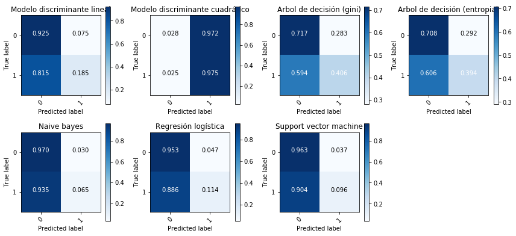

```python
fig = plt.figure(figsize=(12,8))

k = 1
for name,row in ans.iterrows():
    fig.add_subplot(3,4, k)
    plot_confusion_matrix(row['Confusion-Matrix'], classes=['0','1'], normalize = True, title = name)
    k+=1

plt.show()
```

Efectivamente, pese a que en la mayoría de los modelos se obtiene una identificación mayor al 90% de los casos "true positive", el resultado es sumamente malo prediciendo los "true negative". ¿Por qué pasa esto?

¿Cómo solucionarlo? El método más comun -y el que usaremos en este caso- es el de oversampling que consiste balancear las clases artificialmente (haciendo uso de un método llamado SMOTE) y posteriormente entrenar el modelo.

La nueva función queda de la siguiente forma:

```python
def evaluate_model_2(model, data, target, n=10, test_size=.2):
    '''
    Función que recibe un modelo y los datos de entrenamiento. Para n iteraciones se Obtiene una muestra
    del (1-test_size)*100% para la cual ajusta dicho modelo y posteriormente lo evalúa en los datos
    restantes. Se regresan el área promedio bajo la curva ROC, el score de cross-validation promedio,
    la matriz de confusión promedio y el error aparente.
    '''
    scores, matrices, roc_auc  = [],[],[]
    for i in range(n):

        # Partitioning train and test data
        X_train, X_test, y_train, y_test = train_test_split(data, target, test_size=test_size)

        sm = SMOTE()
        X_train, y_train = sm.fit_sample(X_train, y_train['loan_status'].ravel())

        # Fitting model
        model.fit(X_train, y_train)

        # Obtaining Cross-validation score
        scores.append(model.score(X_test, y_test['loan_status']) )

        # Obtaining confusion matrix
        matrices.append(confusion_matrix(y_test['loan_status'], model.predict(X_test)))

        # Obtaining area under the ROC curve
        roc_auc.append(get_roc_auc(model, X_test, y_test))


    # Calculating average confusion matrix
    matrix =  np.mean(matrices,axis=0)

    # Obtaining APER
    APER = 100*(matrix[0,1]+matrix[1,0])/sum(sum(matrix))

    d = {'ROC-AUC': [np.mean(roc_auc)],
         'CV-score': [np.mean(scores)],
         'Confusion-Matrix':[matrix],
         'Covariance-Matrix':[np.cov(matrix).round(1)],
         'APER':[APER]}

    return pd.DataFrame(data=d)
```

Volvemos a evaluar los modelos y graficar las matrices de confusión

```python
ans = pd.DataFrame()
for name,model in models.items():
    df = evaluate_model_2( model, X, y)
    ans = ans.append(df.rename(index={df.index[0]: name}))
ans
```

|  | ROC-AUC | CV-score | Confusion-Matrix | Covariance-Matrix | APER |
| --- | --- | --- | --- | --- | --- |
| Modelo discriminante lineal | 0.635250 | 0.635662 | [[708.4, 404.3], [190.3, 329.0]] | [[46238.4, -21089.3], [-21089.3, 9618.8]] | 36.433824 |
| Modelo discriminante cuadrático | 0.500723 | 0.318811 | [[11.3, 1107.2], [4.5, 509.0]] | [[600498.4, 276440.8], [276440.8, 127260.1]] | 68.118873 |
| Arbol de decisión (gini) | 0.545149 | 0.598223 | [[771.0, 354.0], [301.7, 205.3]] | [[86944.5, 20099.4], [20099.4, 4646.5]] | 40.177696 |
| Arbol de decisión (entropia) | 0.558754 | 0.609314 | [[778.8, 346.8], [290.8, 215.6]] | [[93312.0, 16243.2], [16243.2, 2827.5]] | 39.068627 |
| Naive bayes | 0.580121 | 0.628983 | [[799.3, 326.2], [279.3, 227.2]] | [[111911.8, 12324.3], [12324.3, 1357.2]] | 37.101716 |
| Regresión logística | 0.632075 | 0.630882 | [[701.8, 414.6], [187.8, 327.8]] | [[41241.9, -20104.0], [-20104.0, 9800.0]] | 36.911765 |
| Support vector machine | 0.638585 | 0.634436 | [[700.5, 416.6], [180.0, 334.9]] | [[40299.6, -21988.1], [-21988.1, 11997.0]] | 36.556373 |

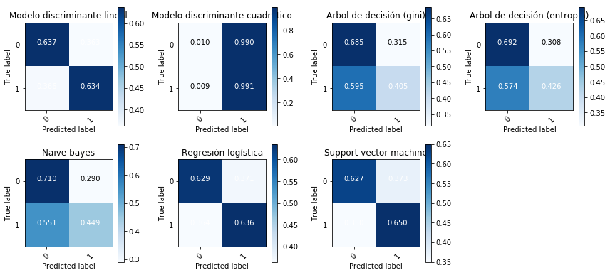

```python
fig = plt.figure(figsize=(12,8))
k = 1
for name,row in ans.iterrows():
    fig.add_subplot(3,4, k)
    plot_confusion_matrix(row['Confusion-Matrix'], classes=['0','1'], normalize = True, title = name)
    k+=1

plt.show()
```

Pese a que el APER aumentó en todos los casos, consideramos que, en general, son mejores modelos puesto que se responde de mejor manera el problema propuesto.

Asimismo, ponderando el APER, el área bajo la curva ROC y las matrices de confusión, consideramos que los mejores modelos son el discriminante lineal, la regresión logística y la máquina de soporte vectorial. En este caso nos quedaremos con la regresión logística.

Considerando todos estos factores, ordenamos de mejor a peor los modelos:

1. Regresión logística - Support vector machine - Modelo discriminante lineal.
2. Naive Bayes.
3. Arbol de decisión (entropia).
4. Arbol de decisión (gini).
5. modelo discriminante cuadrático.

### Clasificando datos de prestamos vigentes

- Usando regresión logística

```python
# Definimos modelo
model = LogisticRegression()

# Oversampling
sm = SMOTE()
X_train, y_train = sm.fit_sample(X, y['loan_status'].ravel())

# Entrenamos modelo
model.fit(X_train,y_train)

# Predecimos
y_to_predict = target.query("loan_status == -1")
X_to_predict = data.loc[y_to_predict.index]
y_predicted = model.predict(X_to_predict[X.columns])
```

```python
y_predicted[:20]
```

```
array([1, 1, 1, 0, 0, 1, 1, 1, 1, 0, 1, 0, 0, 0, 0, 0, 1, 0, 0, 0])
```

```python
str_ = '''
Número de préstamos a predecir: {}
Número de préstamos clasificados a NO ser pagados en tiempo y forma: {}'''.format(len(y_predicted),
                                                                                  sum(y_predicted))
print(str_)
```

```
Número de préstamos a predecir: 56216
Número de préstamos clasificados a NO ser pagados en tiempo y forma: 21114
```